# Projekat iz predmeta Analiza velikih podataka, Raf 2021

## Analiza skupova podataka

#### Ucitavanje podataka

```python
import pandas as pd

# http://archive.ics.uci.edu/ml/datasets/Air+Quality
df_AirQuality_UCI = pd.read_csv("datasets/AirQualityUCI.csv", sep=';', decimal=',')

# http://archive.ics.uci.edu/ml/datasets/PM2.5+Data+of+Five+Chinese+Cities
df_Beijing = pd.read_csv("datasets/BeijingPM20100101_20151231.csv")
#df_Chengdu = pd.read_csv("datasets/ChengduPM20100101_20151231.csv")
#df_Guangzhou = pd.read_csv("datasets/GuangzhouPM20100101_20151231.csv")
#df_Shanghai = pd.read_csv("datasets/ShanghaiPM20100101_20151231.csv")
#df_Shenyang = pd.read_csv("datasets/ShenyangPM20100101_20151231.csv")
```

```python
df_AirQuality_UCI
```

|  | Date | Time | CO(GT) | PT08.S1(CO) | NMHC(GT) | C6H6(GT) | PT08.S2(NMHC) | NOx(GT) | PT08.S3(NOx) | NO2(GT) | PT08.S4(NO2) | PT08.S5(O3) | T | RH | AH | Unnamed: 15 | Unnamed: 16 |
| --- | --- | --- | --- | --- | --- | --- | --- | --- | --- | --- | --- | --- | --- | --- | --- | --- | --- |
| 0 | 10/03/2004 | 18.00.00 | 2.6 | 1360.0 | 150.0 | 11.9 | 1046.0 | 166.0 | 1056.0 | 113.0 | 1692.0 | 1268.0 | 13.6 | 48.9 | 0.7578 | NaN | NaN |
| 1 | 10/03/2004 | 19.00.00 | 2.0 | 1292.0 | 112.0 | 9.4 | 955.0 | 103.0 | 1174.0 | 92.0 | 1559.0 | 972.0 | 13.3 | 47.7 | 0.7255 | NaN | NaN |
| 2 | 10/03/2004 | 20.00.00 | 2.2 | 1402.0 | 88.0 | 9.0 | 939.0 | 131.0 | 1140.0 | 114.0 | 1555.0 | 1074.0 | 11.9 | 54.0 | 0.7502 | NaN | NaN |
| 3 | 10/03/2004 | 21.00.00 | 2.2 | 1376.0 | 80.0 | 9.2 | 948.0 | 172.0 | 1092.0 | 122.0 | 1584.0 | 1203.0 | 11.0 | 60.0 | 0.7867 | NaN | NaN |
| 4 | 10/03/2004 | 22.00.00 | 1.6 | 1272.0 | 51.0 | 6.5 | 836.0 | 131.0 | 1205.0 | 116.0 | 1490.0 | 1110.0 | 11.2 | 59.6 | 0.7888 | NaN | NaN |
| ... | ... | ... | ... | ... | ... | ... | ... | ... | ... | ... | ... | ... | ... | ... | ... | ... | ... |
| 9466 | NaN | NaN | NaN | NaN | NaN | NaN | NaN | NaN | NaN | NaN | NaN | NaN | NaN | NaN | NaN | NaN | NaN |
| 9467 | NaN | NaN | NaN | NaN | NaN | NaN | NaN | NaN | NaN | NaN | NaN | NaN | NaN | NaN | NaN | NaN | NaN |
| 9468 | NaN | NaN | NaN | NaN | NaN | NaN | NaN | NaN | NaN | NaN | NaN | NaN | NaN | NaN | NaN | NaN | NaN |
| 9469 | NaN | NaN | NaN | NaN | NaN | NaN | NaN | NaN | NaN | NaN | NaN | NaN | NaN | NaN | NaN | NaN | NaN |
| 9470 | NaN | NaN | NaN | NaN | NaN | NaN | NaN | NaN | NaN | NaN | NaN | NaN | NaN | NaN | NaN | NaN | NaN |

9471 rows × 17 columns

```python
df_Beijing
```

|  | No | year | month | day | hour | season | PM_Dongsi | PM_Dongsihuan | PM_Nongzhanguan | PM_US Post | DEWP | HUMI | PRES | TEMP | cbwd | Iws | precipitation | Iprec |
| --- | --- | --- | --- | --- | --- | --- | --- | --- | --- | --- | --- | --- | --- | --- | --- | --- | --- | --- |
| 0 | 1 | 2010 | 1 | 1 | 0 | 4 | NaN | NaN | NaN | NaN | -21.0 | 43.0 | 1021.0 | -11.0 | NW | 1.79 | 0.0 | 0.0 |
| 1 | 2 | 2010 | 1 | 1 | 1 | 4 | NaN | NaN | NaN | NaN | -21.0 | 47.0 | 1020.0 | -12.0 | NW | 4.92 | 0.0 | 0.0 |
| 2 | 3 | 2010 | 1 | 1 | 2 | 4 | NaN | NaN | NaN | NaN | -21.0 | 43.0 | 1019.0 | -11.0 | NW | 6.71 | 0.0 | 0.0 |
| 3 | 4 | 2010 | 1 | 1 | 3 | 4 | NaN | NaN | NaN | NaN | -21.0 | 55.0 | 1019.0 | -14.0 | NW | 9.84 | 0.0 | 0.0 |
| 4 | 5 | 2010 | 1 | 1 | 4 | 4 | NaN | NaN | NaN | NaN | -20.0 | 51.0 | 1018.0 | -12.0 | NW | 12.97 | 0.0 | 0.0 |
| ... | ... | ... | ... | ... | ... | ... | ... | ... | ... | ... | ... | ... | ... | ... | ... | ... | ... | ... |
| 52579 | 52580 | 2015 | 12 | 31 | 19 | 4 | 140.0 | 157.0 | 122.0 | 133.0 | -8.0 | 68.0 | 1031.0 | -3.0 | SE | 7.14 | 0.0 | 0.0 |
| 52580 | 52581 | 2015 | 12 | 31 | 20 | 4 | 157.0 | 199.0 | 149.0 | 169.0 | -8.0 | 63.0 | 1030.0 | -2.0 | SE | 8.03 | 0.0 | 0.0 |
| 52581 | 52582 | 2015 | 12 | 31 | 21 | 4 | 171.0 | 231.0 | 196.0 | 203.0 | -10.0 | 73.0 | 1030.0 | -6.0 | NE | 0.89 | 0.0 | 0.0 |
| 52582 | 52583 | 2015 | 12 | 31 | 22 | 4 | 204.0 | 242.0 | 221.0 | 212.0 | -10.0 | 73.0 | 1030.0 | -6.0 | NE | 1.78 | 0.0 | 0.0 |
| 52583 | 52584 | 2015 | 12 | 31 | 23 | 4 | NaN | NaN | NaN | 235.0 | -9.0 | 79.0 | 1029.0 | -6.0 | NE | 2.67 | 0.0 | 0.0 |

52584 rows × 18 columns

### df_AirQuality_UCI analize

```python
data = df_AirQuality_UCI
data.describe(include = "all")
```

|  | Date | Time | CO(GT) | PT08.S1(CO) | NMHC(GT) | C6H6(GT) | PT08.S2(NMHC) | NOx(GT) | PT08.S3(NOx) | NO2(GT) | PT08.S4(NO2) | PT08.S5(O3) | T | RH | AH | Unnamed: 15 | Unnamed: 16 |
| --- | --- | --- | --- | --- | --- | --- | --- | --- | --- | --- | --- | --- | --- | --- | --- | --- | --- |
| count | 9357 | 9357 | 9357.000000 | 9357.000000 | 9357.000000 | 9357.000000 | 9357.000000 | 9357.000000 | 9357.000000 | 9357.000000 | 9357.000000 | 9357.000000 | 9357.000000 | 9357.000000 | 9357.000000 | 0.0 | 0.0 |
| unique | 391 | 24 | NaN | NaN | NaN | NaN | NaN | NaN | NaN | NaN | NaN | NaN | NaN | NaN | NaN | NaN | NaN |
| top | 27/04/2004 | 09.00.00 | NaN | NaN | NaN | NaN | NaN | NaN | NaN | NaN | NaN | NaN | NaN | NaN | NaN | NaN | NaN |
| freq | 24 | 390 | NaN | NaN | NaN | NaN | NaN | NaN | NaN | NaN | NaN | NaN | NaN | NaN | NaN | NaN | NaN |
| mean | NaN | NaN | -34.207524 | 1048.990061 | -159.090093 | 1.865683 | 894.595276 | 168.616971 | 794.990168 | 58.148873 | 1391.479641 | 975.072032 | 9.778305 | 39.485380 | -6.837604 | NaN | NaN |
| std | NaN | NaN | 77.657170 | 329.832710 | 139.789093 | 41.380206 | 342.333252 | 257.433866 | 321.993552 | 126.940455 | 467.210125 | 456.938184 | 43.203623 | 51.216145 | 38.976670 | NaN | NaN |
| min | NaN | NaN | -200.000000 | -200.000000 | -200.000000 | -200.000000 | -200.000000 | -200.000000 | -200.000000 | -200.000000 | -200.000000 | -200.000000 | -200.000000 | -200.000000 | -200.000000 | NaN | NaN |
| 25% | NaN | NaN | 0.600000 | 921.000000 | -200.000000 | 4.000000 | 711.000000 | 50.000000 | 637.000000 | 53.000000 | 1185.000000 | 700.000000 | 10.900000 | 34.100000 | 0.692300 | NaN | NaN |
| 50% | NaN | NaN | 1.500000 | 1053.000000 | -200.000000 | 7.900000 | 895.000000 | 141.000000 | 794.000000 | 96.000000 | 1446.000000 | 942.000000 | 17.200000 | 48.600000 | 0.976800 | NaN | NaN |
| 75% | NaN | NaN | 2.600000 | 1221.000000 | -200.000000 | 13.600000 | 1105.000000 | 284.000000 | 960.000000 | 133.000000 | 1662.000000 | 1255.000000 | 24.100000 | 61.900000 | 1.296200 | NaN | NaN |
| max | NaN | NaN | 11.900000 | 2040.000000 | 1189.000000 | 63.700000 | 2214.000000 | 1479.000000 | 2683.000000 | 340.000000 | 2775.000000 | 2523.000000 | 44.600000 | 88.700000 | 2.231000 | NaN | NaN |

##### Podaci o skupu podataka:

Skup podataka sadrži 9358 primeraka prosečnih odgovora po satu iz niza od 5 hemijskih senzora metalnih oksida ugrađenih u uređaj za hemijski multisenzor kvaliteta vazduha. Uređaj se nalazio na terenu u značajno zagađenom području, na nivou puta, u okviru italijanskog grada.

Dokazi o unakrsnoj osetljivosti, kao i pomeranja koncepta i senzora su prisutni kako je opisano u De Vito et al., Sens. And Act. B, vol. 129,2,2008 (potreban navod) koji na kraju utiče na mogućnosti procene koncentracije senzora. **Nedostajuće vrednosti su označene sa -200 vrednoscu .** Ovaj skup podataka može se koristiti isključivo u istraživačke svrhe. Komercijalne svrhe su u potpunosti isključene.

##### Informacije o atributima:

| Atribut | originalni opis atributa) |
| --- | --- |
| Date | Date (DD/MM/YYYY) |
| Time | Time (HH.MM.SS) |
| CO(GT) | True hourly averaged concentration CO in mg/m^3 (reference analyzer) |
| PT08.S1(CO) | PT08.S1 (tin oxide) hourly averaged sensor response (nominally CO targeted) |
| NMHC(GT) | Non Metanic HydroCarbons concentration in microg/m^3 (reference analyzer) |
| C6H6(GT) | True hourly averaged Benzene concentration in microg/m^3 (reference analyzer) |
| PT08.S2(NMHC) | PT08.S2 (titania) hourly averaged sensor response (nominally NMHC targeted) |
| NOx (GT) | True hourly averaged NOx concentration in ppb (reference analyzer) |
| PT08.S3(NOx) | PT08.S3 (tungsten oxide) hourly averaged sensor response |
| NO2(GT) | True hourly averaged NO2 concentration in microg/m^3 (reference analyzer) |
| PT08.S4(NO2) | PT08.S4 (tungsten oxide) hourly averaged sensor response |
| PT08.S5(O3) | PT08.S5 (indium oxide) hourly averaged sensor response (nominally O3 targeted) |
| T | Temperature in Â°C |
| RH | Relative Humidity (%) |
| AH | AH Absolute Humidity |

Jedan mesec ocitavanja na sat vremena za zagadjivace:

- tin oxide (PT08.S1.CO);
- titanium (PT08.S2.NMHC);
- tungsten oxide (PT08.S4.NOx, PT08.S4.NO2);
- indium oxide (PT08.S5.O3).

Atributi koji se mogu iskoristiti za predvidjanje:

- sat u danu;
- temperatura;
- relativna vlažnost;
- apsolutna vlažnost.

```python
import seaborn as sns
import matplotlib.pyplot as plt

def features_countplot(df):
    fig, axs = plt.subplots(4, 4, figsize=(25,30), constrained_layout=True)
    for i, f in enumerate(df.columns):
        sns.countplot(x=f, data=df, ax=axs[i//4][i%4], palette="Set1")
    plt.show()
```

#### Ciscenje podataka

```python
data.isnull().sum()
```

```
Date              114
Time              114
CO(GT)            114
PT08.S1(CO)       114
NMHC(GT)          114
C6H6(GT)          114
PT08.S2(NMHC)     114
NOx(GT)           114
PT08.S3(NOx)      114
NO2(GT)           114
PT08.S4(NO2)      114
PT08.S5(O3)       114
T                 114
RH                114
AH                114
Unnamed: 15      9471
Unnamed: 16      9471
dtype: int64
```

```python
data = data.drop(columns=['Unnamed: 15', 'Unnamed: 16']).dropna(axis='index')
```

```python
data.isnull().sum()
```

```
Date             0
Time             0
CO(GT)           0
PT08.S1(CO)      0
NMHC(GT)         0
C6H6(GT)         0
PT08.S2(NMHC)    0
NOx(GT)          0
PT08.S3(NOx)     0
NO2(GT)          0
PT08.S4(NO2)     0
PT08.S5(O3)      0
T                0
RH               0
AH               0
dtype: int64
```

```python
data['Date'] = pd.to_datetime(data['Date'], format='%d/%m/%Y')
data = data.set_index('Date')
```

```python
data = data.groupby(data.index).max()
data = data.replace([-200], method='bfill')
```

```python
data.describe()
```

|  | CO(GT) | PT08.S1(CO) | NMHC(GT) | C6H6(GT) | PT08.S2(NMHC) | NOx(GT) | PT08.S3(NOx) | NO2(GT) | PT08.S4(NO2) | PT08.S5(O3) | T | RH | AH |
| --- | --- | --- | --- | --- | --- | --- | --- | --- | --- | --- | --- | --- | --- |
| count | 391.000000 | 391.000000 | 391.000000 | 391.000000 | 391.000000 | 391.000000 | 391.000000 | 391.000000 | 391.000000 | 391.000000 | 391.000000 | 391.000000 | 391.000000 |
| mean | 4.551407 | 1406.544757 | -89.079284 | 22.653453 | 1342.521739 | 485.856777 | 1196.890026 | 167.580563 | 1889.465473 | 1573.915601 | 24.083887 | 65.759591 | 1.171862 |
| std | 1.946131 | 235.150857 | 297.065237 | 10.064430 | 268.067335 | 305.176594 | 283.856041 | 50.593078 | 421.232749 | 394.500113 | 9.790347 | 12.551643 | 0.424818 |
| min | 0.100000 | 861.000000 | -200.000000 | 3.400000 | 678.000000 | 72.000000 | 530.000000 | 68.000000 | 825.000000 | 556.000000 | 4.000000 | 33.000000 | 0.269300 |
| 25% | 3.000000 | 1222.500000 | -200.000000 | 14.100000 | 1118.500000 | 247.000000 | 1002.500000 | 128.000000 | 1602.000000 | 1285.000000 | 15.700000 | 55.050000 | 0.866850 |
| 50% | 4.400000 | 1403.000000 | -200.000000 | 22.300000 | 1359.000000 | 379.000000 | 1156.000000 | 166.000000 | 1874.000000 | 1579.000000 | 23.600000 | 67.100000 | 1.129800 |
| 75% | 5.700000 | 1565.500000 | -200.000000 | 29.100000 | 1530.000000 | 691.000000 | 1326.000000 | 196.000000 | 2232.500000 | 1830.500000 | 32.100000 | 76.400000 | 1.479250 |
| max | 11.900000 | 2040.000000 | 1189.000000 | 63.700000 | 2214.000000 | 1479.000000 | 2683.000000 | 340.000000 | 2775.000000 | 2523.000000 | 44.600000 | 88.700000 | 2.231000 |

```python
data.shape
```

```
(391, 14)
```

```python
data.agg(['median'])
```

|  | CO(GT) | PT08.S1(CO) | NMHC(GT) | C6H6(GT) | PT08.S2(NMHC) | NOx(GT) | PT08.S3(NOx) | NO2(GT) | PT08.S4(NO2) | PT08.S5(O3) | T | RH | AH |
| --- | --- | --- | --- | --- | --- | --- | --- | --- | --- | --- | --- | --- | --- |
| median | 4.4 | 1403.0 | -200.0 | 22.3 | 1359.0 | 379.0 | 1156.0 | 166.0 | 1874.0 | 1579.0 | 23.6 | 67.1 | 1.1298 |

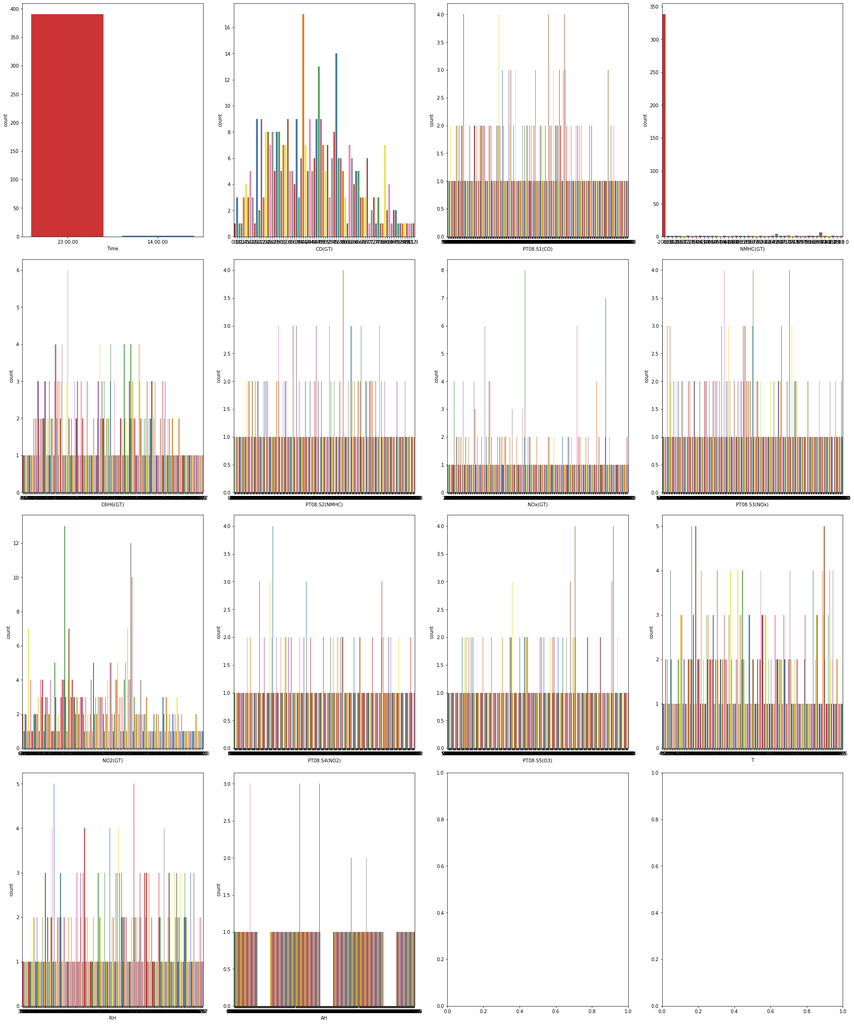

```python
features_countplot(data)
```

Napisana je skripta za vizuelizaciju merenja na senozorima po kalendarskim danima.

### Kalendarske mape - sezonalnost

```python
import numpy as np
import pandas as pd
import matplotlib.pyplot as plt
from matplotlib.patches import Polygon

days = ['Pon', 'Uto', 'Sre', 'Cet', 'Pet', 'Sub', 'Ned']
month_names = ['Januar', 'Februar', 'Mart', 'April', 'Maj', 'Jun', 'Jul', 'Avgust',
               'Septembar', 'Oktobar', 'Novembar', 'Decembar']
weeks = [1, 2, 3, 4, 5, 6]

def generate_data():
    idx = pd.date_range('2004-01-01', periods=365, freq='D')
    return pd.Series(range(len(idx)), index=idx)

def split_months(df, year):

    df = df[df.index.year == year]

    a = np.empty((6, 7))
    a[:] = np.nan

    day_nums = {m:np.copy(a) for m in range(1,13)}
    day_vals = {m:np.copy(a) for m in range(1,13)}

    for d in df.iteritems():  # iterrows za DataFrame

        day = d[0].day
        month = d[0].month
        col = d[0].dayofweek

        if d[0].is_month_start:
            row = 0

        day_nums[month][row, col] = day
        day_vals[month][row, col] = d[1]

        if col == 6:
            row += 1

    return day_nums, day_vals


def create_year_calendar(day_nums, day_vals, df, titleText):
    fig, ax = plt.subplots(3, 4, figsize=(14.85, 10.5))

    for i, axs in enumerate(ax.flat):

        axs.imshow(day_vals[i+1], cmap='viridis', vmin=df.min(), vmax=df.max())
        axs.set_title(month_names[i])

        axs.set_xticks(np.arange(len(days)))
        axs.set_xticklabels(days, fontsize=10, fontweight='bold', color='#555555')
        axs.set_yticklabels([])

        axs.tick_params(axis=u'both', which=u'both', length=0)
        axs.xaxis.tick_top()


        axs.set_xticks(np.arange(-.5, 6, 1), minor=True)
        axs.set_yticks(np.arange(-.5, 5, 1), minor=True)
        axs.grid(which='minor', color='w', linestyle='-', linewidth=2.1)


        for edge in ['left', 'right', 'bottom', 'top']:
            axs.spines[edge].set_color('#FFFFFF')


        for w in range(len(weeks)):
            for d in range(len(days)):
                day_val = day_vals[i+1][w, d]
                day_num = day_nums[i+1][w, d]


                axs.text(d, w+0.3, f"{day_val:0.0f}",
                         ha="center", va="center",
                         fontsize=7, color="w", alpha=0.8)


                if day_val == 0:
                    patch_coords = ((d - 0.5, w - 0.5),
                                    (d - 0.5, w + 0.5),
                                    (d + 0.5, w + 0.5),
                                    (d + 0.5, w - 0.5))

                    square = Polygon(patch_coords, fc='#DDDDDD')
                    axs.add_artist(square)


                if not np.isnan(day_num):
                    axs.text(d+0.45, w-0.31, f"{day_num:0.0f}",
                             ha="right", va="center",
                             fontsize=6, color="#003333", alpha=0.8)  # day

                patch_coords = ((d-0.1, w-0.5),
                                (d+0.5, w-0.5),
                                (d+0.5, w+0.1))

                triangle = Polygon(patch_coords, fc='w', alpha=0.7)
                axs.add_artist(triangle)

    fig.suptitle(titleText, fontsize=16)
    plt.subplots_adjust(left=0.04, right=0.96, top=0.88, bottom=0.04)

    #plt.savefig('calendar_example.pdf')
    plt.show()

def generate_data1(df, year):
    idx = pd.date_range(year +'-01-01', periods=365, freq='D')
    return pd.Series(df.astype('int64'), index=idx)

def CalendarHeat(df, year):
    df1 = generate_data1(df, str(year))
    day_nums, day_vals = split_months(df1, year)
    create_year_calendar(day_nums, day_vals, df1, df.name)
```

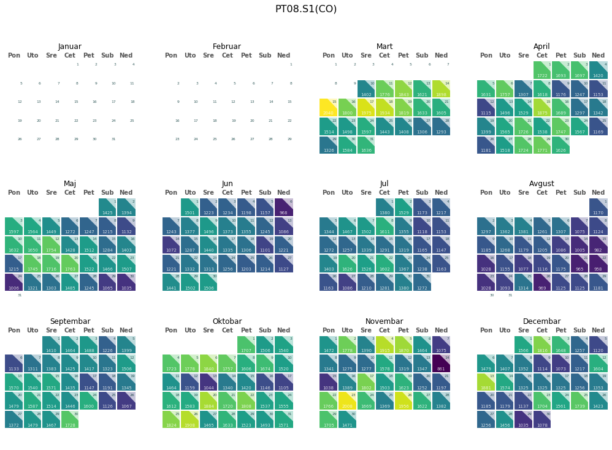

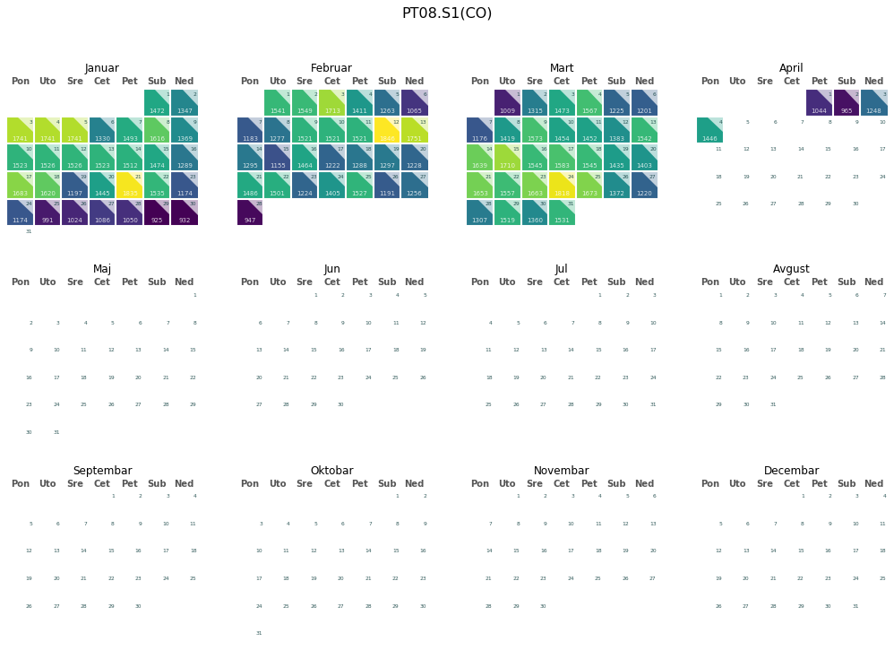

```python
CalendarHeat(data['PT08.S1(CO)'], 2004)
CalendarHeat(data['PT08.S1(CO)'], 2005)
```

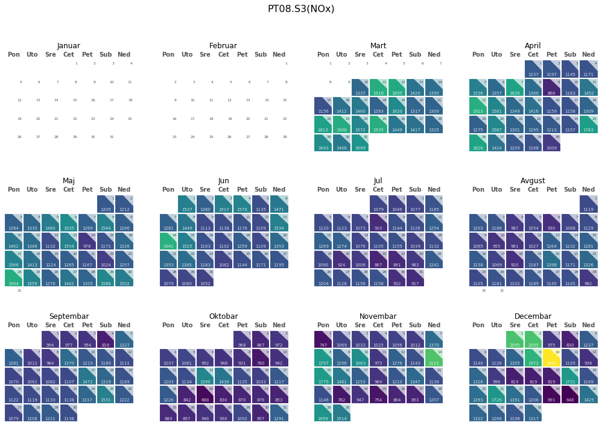

```python
CalendarHeat(data['PT08.S3(NOx)'], 2004)
```

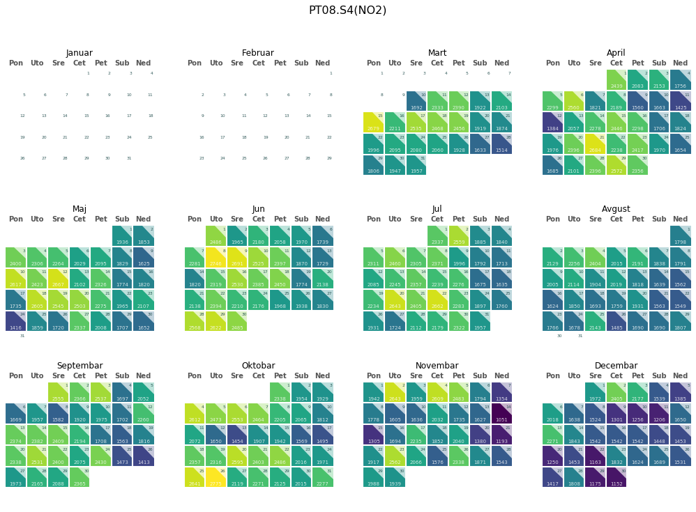

```python
CalendarHeat(data['PT08.S4(NO2)'], 2004)
```

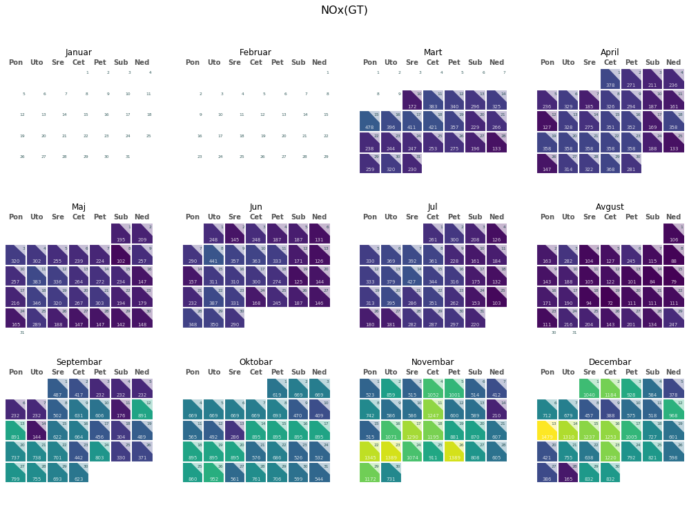

```python
CalendarHeat(data['NOx(GT)'], 2004)
```

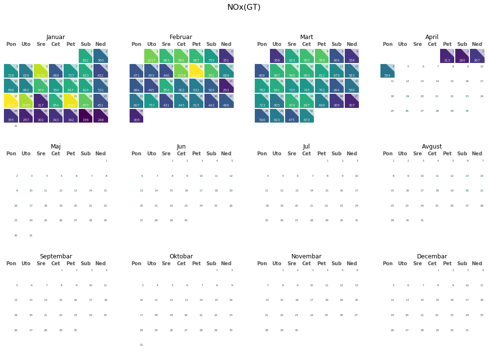

```python
CalendarHeat(data['NOx(GT)'], 2005)
```

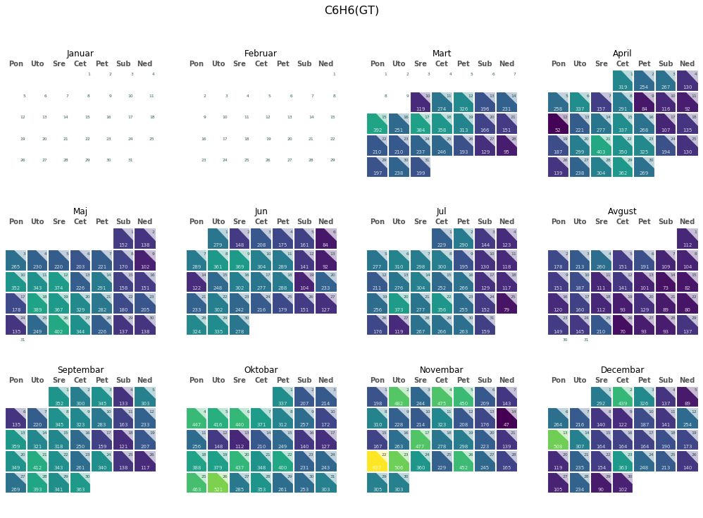

```python
CalendarHeat(data['C6H6(GT)']*10, 2004)
```

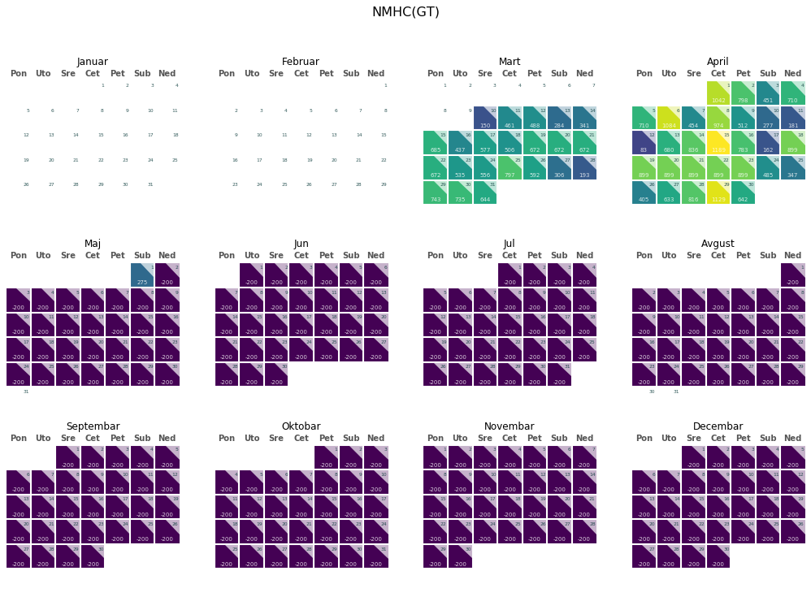

```python
CalendarHeat(data['NMHC(GT)'], 2004)
```

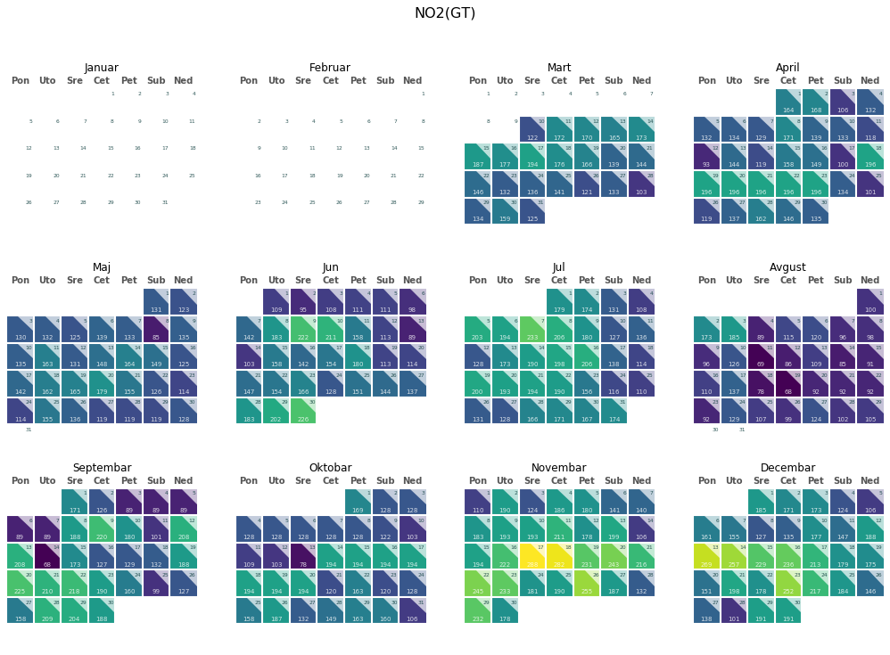

```python
CalendarHeat(data['NO2(GT)'], 2004)
```

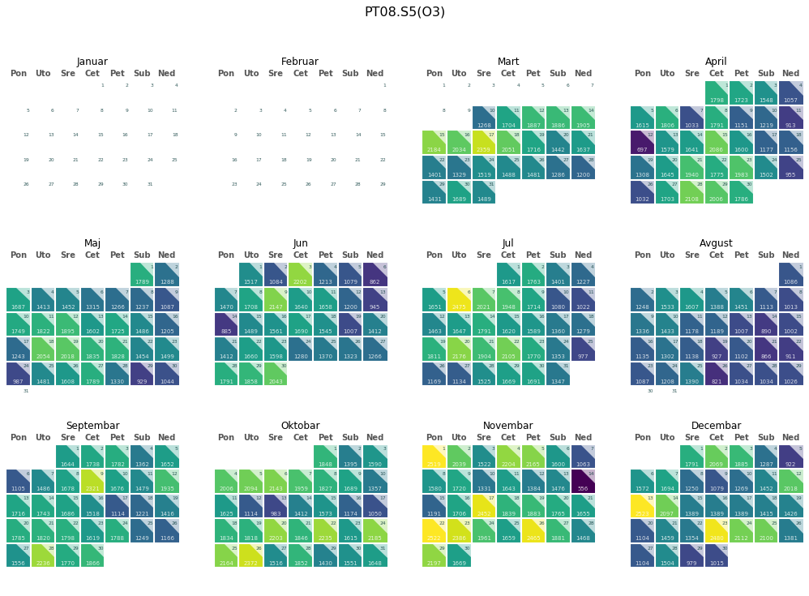

```python
CalendarHeat(data['PT08.S5(O3)'], 2004)
```

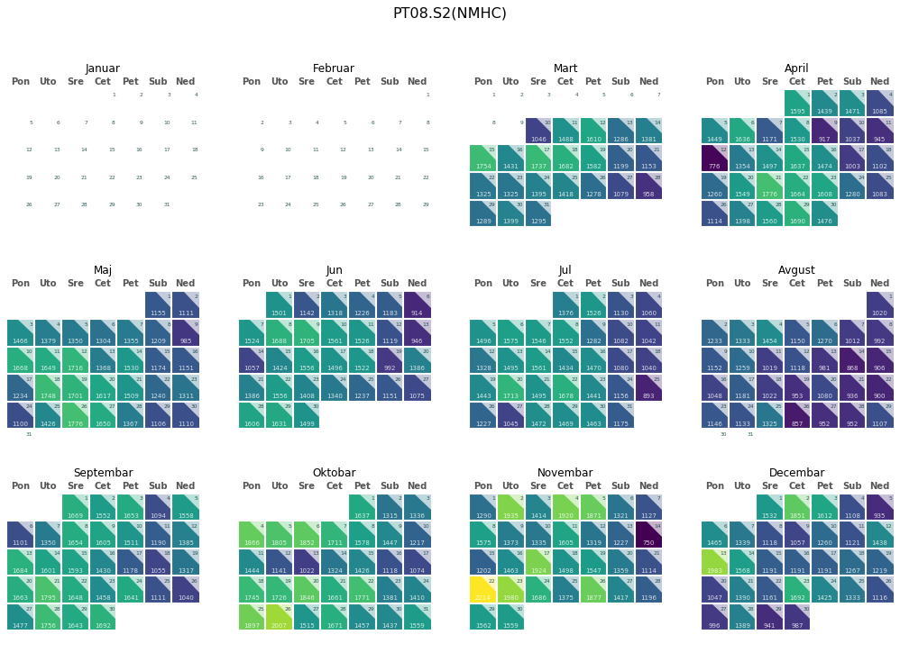

```python
CalendarHeat(data['PT08.S2(NMHC)'], 2004)
```

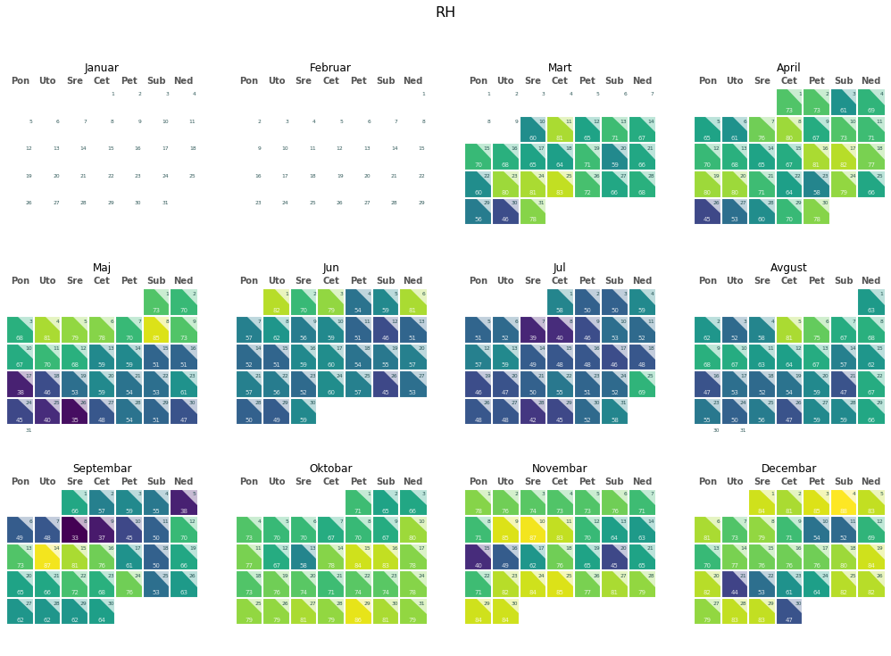

```python
CalendarHeat(data['RH'], 2004)
```

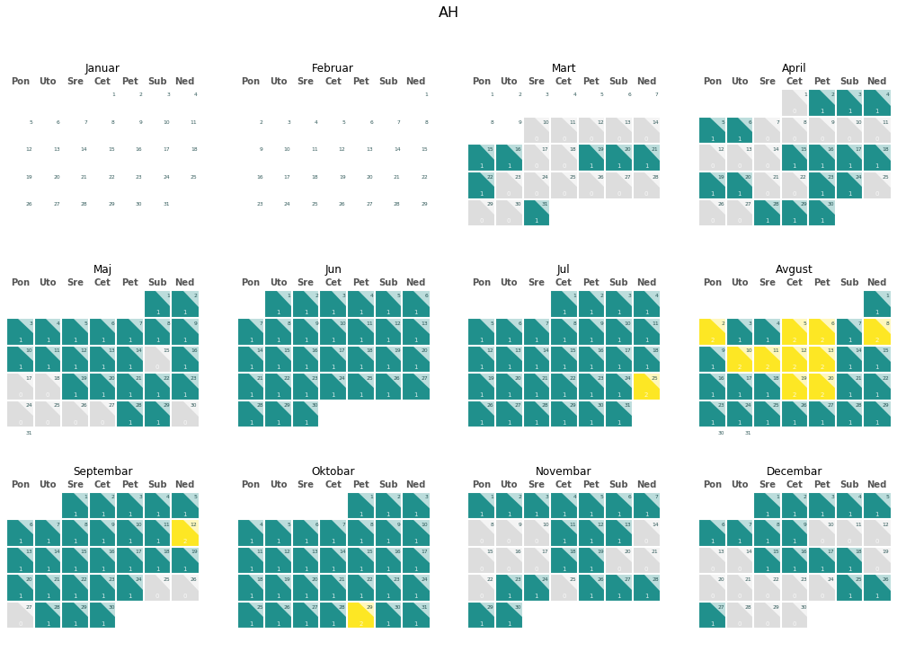

```python
CalendarHeat(data['AH'], 2004)
```

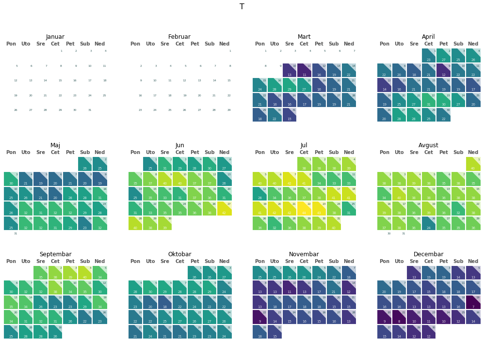

```python
CalendarHeat(data['T'], 2004)
```

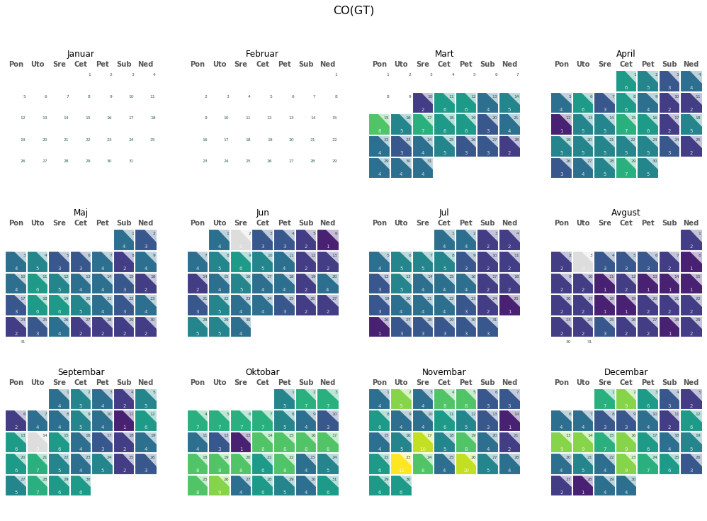

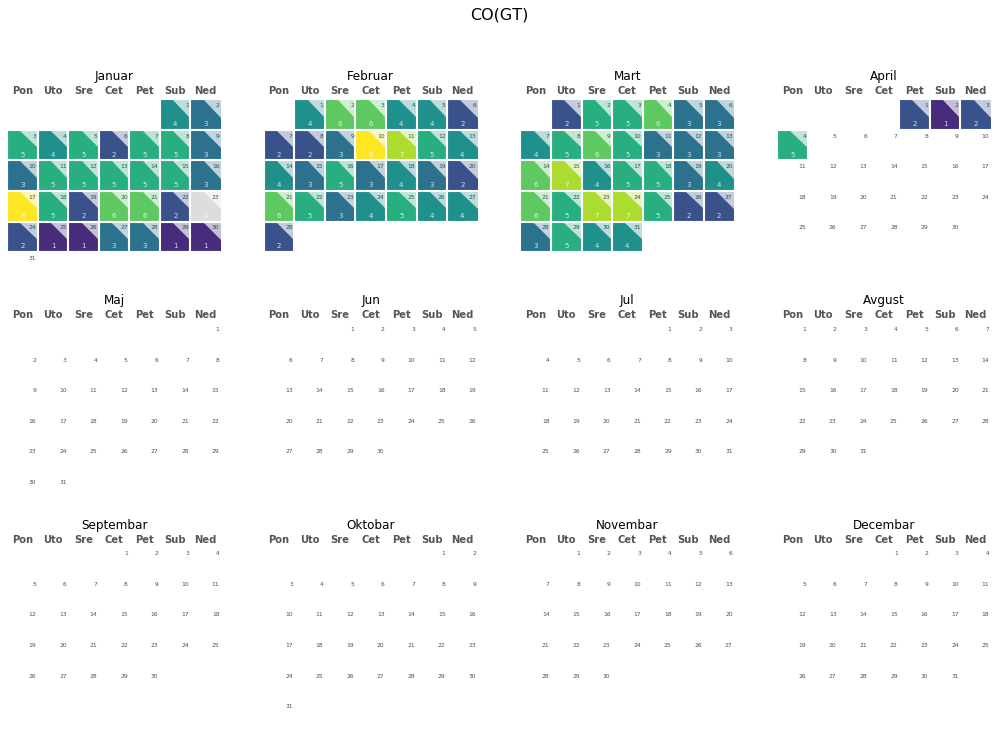

```python
CalendarHeat(data['CO(GT)'], 2004)
CalendarHeat(data['CO(GT)'], 2005)
```

### Brisanje suvisnog NMHC

```python
del data['NMHC(GT)']
```

### Ispitivanje korelacija

```python
data.corr()
```

|  | CO(GT) | PT08.S1(CO) | C6H6(GT) | PT08.S2(NMHC) | NOx(GT) | PT08.S3(NOx) | NO2(GT) | PT08.S4(NO2) | PT08.S5(O3) | T | RH | AH |
| --- | --- | --- | --- | --- | --- | --- | --- | --- | --- | --- | --- | --- |
| CO(GT) | 1.000000 | 0.749829 | 0.765089 | 0.761648 | 0.746463 | -0.208357 | 0.526435 | 0.463654 | 0.730882 | -0.202413 | 0.315620 | -0.069197 |
| PT08.S1(CO) | 0.749829 | 1.000000 | 0.809992 | 0.820310 | 0.500042 | -0.295897 | 0.360392 | 0.643170 | 0.856622 | -0.067436 | 0.352636 | 0.042314 |
| C6H6(GT) | 0.765089 | 0.809992 | 1.000000 | 0.992787 | 0.486534 | -0.184039 | 0.326726 | 0.762410 | 0.816617 | 0.139810 | 0.134033 | 0.136459 |
| PT08.S2(NMHC) | 0.761648 | 0.820310 | 0.992787 | 1.000000 | 0.478490 | -0.194462 | 0.331582 | 0.776545 | 0.831381 | 0.154620 | 0.139453 | 0.142766 |
| NOx(GT) | 0.746463 | 0.500042 | 0.486534 | 0.478490 | 1.000000 | -0.311553 | 0.720114 | -0.014727 | 0.601202 | -0.486410 | 0.375898 | -0.286882 |
| PT08.S3(NOx) | -0.208357 | -0.295897 | -0.184039 | -0.194462 | -0.311553 | 1.000000 | -0.229965 | -0.136102 | -0.387965 | -0.158156 | -0.148448 | -0.259063 |
| NO2(GT) | 0.526435 | 0.360392 | 0.326726 | 0.331582 | 0.720114 | -0.229965 | 1.000000 | -0.113383 | 0.535186 | -0.424372 | 0.088519 | -0.508835 |
| PT08.S4(NO2) | 0.463654 | 0.643170 | 0.762410 | 0.776545 | -0.014727 | -0.136102 | -0.113383 | 1.000000 | 0.537849 | 0.566322 | 0.064315 | 0.565354 |
| PT08.S5(O3) | 0.730882 | 0.856622 | 0.816617 | 0.831381 | 0.601202 | -0.387965 | 0.535186 | 0.537849 | 1.000000 | -0.013477 | 0.172875 | -0.034942 |
| T | -0.202413 | -0.067436 | 0.139810 | 0.154620 | -0.486410 | -0.158156 | -0.424372 | 0.566322 | -0.013477 | 1.000000 | -0.419826 | 0.732046 |
| RH | 0.315620 | 0.352636 | 0.134033 | 0.139453 | 0.375898 | -0.148448 | 0.088519 | 0.064315 | 0.172875 | -0.419826 | 1.000000 | 0.085393 |
| AH | -0.069197 | 0.042314 | 0.136459 | 0.142766 | -0.286882 | -0.259063 | -0.508835 | 0.565354 | -0.034942 | 0.732046 | 0.085393 | 1.000000 |

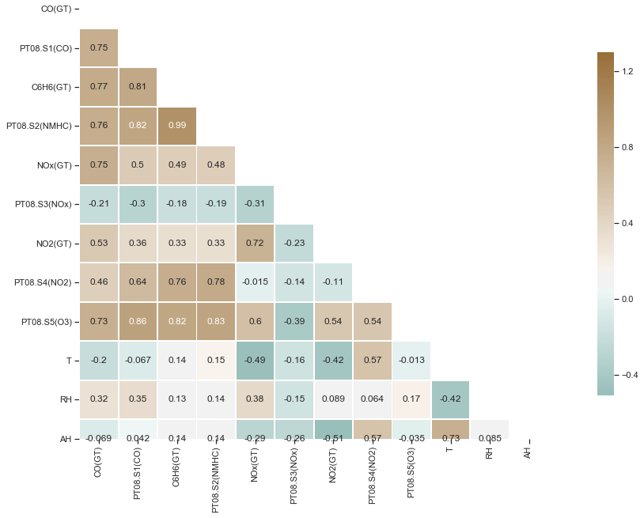

```python
sns.set(style="ticks")

corr = data.corr()

mask = np.zeros_like(corr, dtype=np.bool)
mask[np.triu_indices_from(mask)] = True

f, ax = plt.subplots(figsize=(22, 10))
cmap = sns.diverging_palette(180, 50, as_cmap=True)

sns.heatmap(corr, mask=mask, cmap=cmap, vmax=1.3, center=0.1,annot=True,
            square=True, linewidths=.9, cbar_kws={"shrink": 0.8})
```

### Usrednjavanje na nivou vremenskih prozora

```python
from itertools import compress, product

def combinations(items):
    return (set(compress(items,mask)) for mask in product(*[[0,1]]*len(items)))
```

```python
measurementsColumns = ['CO(GT)','PT08.S1(CO)','C6H6(GT)','PT08.S2(NMHC)','NOx(GT)','PT08.S3(NOx)','NO2(GT)','PT08.S4(NO2)','PT08.S5(O3)','T','RH','AH']
all_columns = measurementsColumns + ['Date', 'Time']
trainnCols = ['PT08.S1(CO)','C6H6(GT)','NO2(GT)','T','RH','AH']
```

```python
def get_averaged_splices(df, samples):
    length = len(df.index)
    num_of_rows_to_group = samples
    parts = int(length / num_of_rows_to_group)
    #print(parts)
    dfs = []
    for i in range(parts):
        df_slice = df[i*num_of_rows_to_group : (i+1)*num_of_rows_to_group]
        dfm = df_slice.mean(axis=0).T
        #dfm['Date'] = df_slice['Date'].iloc[0]
        #dfm['Time'] = df_slice['Time'].iloc[0]
        #dfm = dfm[ ['Date', 'Time'] + measurementsColumns]
        dfm = dfm[measurementsColumns]
        dfs.append(dfm)
    dfm_summary = pd.concat(dfs, axis=1).T
    #print(dfm_summary)
    #dfm_summary.to_csv("sensor_data_" + str(samples) + "samples.csv")
    return dfm_summary
```

```python
df_summ3 = get_averaged_splices(data, 3)
df_summ3
```

|  | CO(GT) | PT08.S1(CO) | C6H6(GT) | PT08.S2(NMHC) | NOx(GT) | PT08.S3(NOx) | NO2(GT) | PT08.S4(NO2) | PT08.S5(O3) | T | RH | AH |
| --- | --- | --- | --- | --- | --- | --- | --- | --- | --- | --- | --- | --- |
| 0 | 5.366667 | 1673.666667 | 23.966667 | 1381.333333 | 298.333333 | 1716.666667 | 154.666667 | 2138.333333 | 1619.666667 | 13.933333 | 69.000000 | 0.814567 |
| 1 | 6.066667 | 1853.000000 | 27.300000 | 1473.666667 | 366.333333 | 1323.666667 | 175.000000 | 2234.666667 | 1991.666667 | 22.000000 | 70.000000 | 0.949300 |
| 2 | 6.500000 | 1903.000000 | 33.100000 | 1616.666667 | 409.333333 | 1388.333333 | 182.333333 | 2404.666667 | 2148.000000 | 28.200000 | 65.966667 | 0.979800 |
| 3 | 4.800000 | 1685.666667 | 21.000000 | 1311.333333 | 284.000000 | 1412.333333 | 149.666667 | 2083.000000 | 1598.333333 | 19.100000 | 65.433333 | 1.041767 |
| 4 | 4.266667 | 1536.333333 | 21.900000 | 1348.333333 | 243.000000 | 1764.333333 | 138.000000 | 2057.000000 | 1416.333333 | 18.066667 | 74.033333 | 1.004067 |
| ... | ... | ... | ... | ... | ... | ... | ... | ... | ... | ... | ... | ... |
| 125 | 5.400000 | 1537.666667 | 24.533333 | 1404.666667 | 639.333333 | 993.000000 | 203.000000 | 1870.000000 | 1718.666667 | 24.133333 | 70.300000 | 1.056167 |
| 126 | 6.800000 | 1718.000000 | 31.766667 | 1589.666667 | 790.000000 | 879.333333 | 219.333333 | 2042.000000 | 2033.333333 | 23.433333 | 73.100000 | 1.202633 |
| 127 | 2.766667 | 1299.666667 | 10.300000 | 982.000000 | 394.666667 | 848.000000 | 143.000000 | 1453.000000 | 1273.333333 | 23.133333 | 78.500000 | 1.330133 |
| 128 | 4.466667 | 1470.000000 | 23.266667 | 1383.333333 | 590.333333 | 1080.000000 | 181.333333 | 1834.666667 | 1740.333333 | 23.400000 | 74.633333 | 1.149267 |
| 129 | 2.133333 | 1085.666667 | 8.100000 | 898.333333 | 320.000000 | 1199.333333 | 173.666667 | 1135.000000 | 1056.666667 | 23.966667 | 48.866667 | 0.753633 |

130 rows × 12 columns

```python
df_summ5 = get_averaged_splices(data, 5)
df_summ7 = get_averaged_splices(data, 7)
df_summ10 = get_averaged_splices(data, 10)

print(df_summ5.shape)
print(df_summ7.shape)
print(df_summ10.shape)
```

```
(78, 12)
(55, 12)
(39, 12)
```

```python
combs = list(combinations(trainnCols))
combs.pop(0)
len(combs)
```

```
63
```

```python
combs
```

```
[{'AH'},
 {'RH'},
 {'AH', 'RH'},
 {'T'},
 {'AH', 'T'},
 {'RH', 'T'},
 {'AH', 'RH', 'T'},
 {'NO2(GT)'},
 {'AH', 'NO2(GT)'},
 {'NO2(GT)', 'RH'},
 {'AH', 'NO2(GT)', 'RH'},
 {'NO2(GT)', 'T'},
 {'AH', 'NO2(GT)', 'T'},
 {'NO2(GT)', 'RH', 'T'},
 {'AH', 'NO2(GT)', 'RH', 'T'},
 {'C6H6(GT)'},
 {'AH', 'C6H6(GT)'},
 {'C6H6(GT)', 'RH'},
 {'AH', 'C6H6(GT)', 'RH'},
 {'C6H6(GT)', 'T'},
 {'AH', 'C6H6(GT)', 'T'},
 {'C6H6(GT)', 'RH', 'T'},
 {'AH', 'C6H6(GT)', 'RH', 'T'},
 {'C6H6(GT)', 'NO2(GT)'},
 {'AH', 'C6H6(GT)', 'NO2(GT)'},
 {'C6H6(GT)', 'NO2(GT)', 'RH'},
 {'AH', 'C6H6(GT)', 'NO2(GT)', 'RH'},
 {'C6H6(GT)', 'NO2(GT)', 'T'},
 {'AH', 'C6H6(GT)', 'NO2(GT)', 'T'},
 {'C6H6(GT)', 'NO2(GT)', 'RH', 'T'},
 {'AH', 'C6H6(GT)', 'NO2(GT)', 'RH', 'T'},
 {'PT08.S1(CO)'},
 {'AH', 'PT08.S1(CO)'},
 {'PT08.S1(CO)', 'RH'},
 {'AH', 'PT08.S1(CO)', 'RH'},
 {'PT08.S1(CO)', 'T'},
 {'AH', 'PT08.S1(CO)', 'T'},
 {'PT08.S1(CO)', 'RH', 'T'},
 {'AH', 'PT08.S1(CO)', 'RH', 'T'},
 {'NO2(GT)', 'PT08.S1(CO)'},
```

[output cut: 8 more lines]

```
 {'AH', 'C6H6(GT)', 'PT08.S1(CO)'},
 {'C6H6(GT)', 'PT08.S1(CO)', 'RH'},
 {'AH', 'C6H6(GT)', 'PT08.S1(CO)', 'RH'},
 {'C6H6(GT)', 'PT08.S1(CO)', 'T'},
 {'AH', 'C6H6(GT)', 'PT08.S1(CO)', 'T'},
 {'C6H6(GT)', 'PT08.S1(CO)', 'RH', 'T'},
 {'AH', 'C6H6(GT)', 'PT08.S1(CO)', 'RH', 'T'},
 {'C6H6(GT)', 'NO2(GT)', 'PT08.S1(CO)'},
 {'AH', 'C6H6(GT)', 'NO2(GT)', 'PT08.S1(CO)'},
 {'C6H6(GT)', 'NO2(GT)', 'PT08.S1(CO)', 'RH'},
 {'AH', 'C6H6(GT)', 'NO2(GT)', 'PT08.S1(CO)', 'RH'},
 {'C6H6(GT)', 'NO2(GT)', 'PT08.S1(CO)', 'T'},
 {'AH', 'C6H6(GT)', 'NO2(GT)', 'PT08.S1(CO)', 'T'},
 {'C6H6(GT)', 'NO2(GT)', 'PT08.S1(CO)', 'RH', 'T'},
 {'AH', 'C6H6(GT)', 'NO2(GT)', 'PT08.S1(CO)', 'RH', 'T'}]
```

```python
from sklearn import datasets, linear_model
from sklearn.model_selection import train_test_split
from sklearn.model_selection import cross_val_score, cross_val_predict
from sklearn import metrics
```

```python
def GetAccuracy(df_all_data, training_columns, predicting_columns):

    df = df_all_data[training_columns]
    y = df_all_data[predicting_columns]

    # create training and testing vars
    X_train, X_test, y_train, y_test = train_test_split(df, y, test_size=0.2)
    #print (X_train.shape, y_train.shape)
    #print (X_test.shape, y_test.shape)

    # fit a model
    lm = linear_model.LinearRegression()
    model = lm.fit(X_train, y_train)
    predictions = lm.predict(X_test)

    ## The line / model
    #plt.scatter(y_test, predictions)
    #plt.xlabel('True Values')
    #plt.ylabel('Predictions')

    accuracy = metrics.r2_score(y_test, predictions)
    return accuracy
```

```python
results = dict()
files=['1', '3', '5', '7', '10']

combsStrings = []

for comb in combs:
    combsStrings.append(str(comb))

df_results = pd.DataFrame(results, columns = files, index=combsStrings)
```

```python
for file in files:
    print("Radi se file: " + file)
    for training_columns in combs:
        predicting_columns = ['CO(GT)']
        windowedDf = get_averaged_splices(data, int(file))
        accuracy = GetAccuracy(windowedDf, training_columns, predicting_columns)
        df_results[file][str(training_columns)] = accuracy
```

```
Radi se file: 1
Radi se file: 3
Radi se file: 5
Radi se file: 7
Radi se file: 10
```

```python
df_results
```

|  | 1 | 3 | 5 | 7 | 10 |
| --- | --- | --- | --- | --- | --- |
| {'AH'} | -0.0095619 | -0.0627174 | -0.631118 | -0.134046 | -1.94465 |
| {'RH'} | 0.111523 | 0.331276 | -0.0301652 | -0.00692542 | 0.430604 |
| {'RH', 'AH'} | -0.0341642 | 0.0539345 | 0.064972 | 0.45407 | 0.291017 |
| {'T'} | 0.0667355 | -0.028022 | 0.200654 | 0.391761 | 0.420771 |
| {'AH', 'T'} | 0.0789889 | 0.14776 | 0.0752044 | 0.326129 | -2.40615 |
| ... | ... | ... | ... | ... | ... |
| {'NO2(GT)', 'C6H6(GT)', 'RH', 'AH', 'PT08.S1(CO)'} | 0.685512 | 0.78329 | 0.528226 | 0.840012 | 0.932575 |
| {'NO2(GT)', 'PT08.S1(CO)', 'T', 'C6H6(GT)'} | 0.817019 | 0.891861 | 0.553841 | 0.126862 | 0.777128 |
| {'NO2(GT)', 'C6H6(GT)', 'AH', 'PT08.S1(CO)', 'T'} | 0.684505 | 0.86458 | 0.671511 | 0.405175 | 0.837573 |
| {'NO2(GT)', 'C6H6(GT)', 'RH', 'PT08.S1(CO)', 'T'} | 0.783439 | 0.738146 | 0.635142 | 0.948283 | 0.751204 |
| {'NO2(GT)', 'C6H6(GT)', 'RH', 'AH', 'PT08.S1(CO)', 'T'} | 0.786547 | 0.629862 | 0.681884 | 0.602507 | 0.453328 |

63 rows × 5 columns

```python
df_results.to_csv("averaged_windows1.csv")
```

```python
stats = pd.DataFrame([], columns = df_results.columns, index=['max', 'comb_id', 'korisceni atributi za trening'])
```

```python
df_results = df_results.astype('float64')
```

```python
df_results = df_results.reset_index()
```

```python
df_results.head()
```

|  | index | 1 | 3 | 5 | 7 | 10 |
| --- | --- | --- | --- | --- | --- | --- |
| 0 | {'AH'} | -0.009562 | -0.062717 | -0.631118 | -0.134046 | -1.944646 |
| 1 | {'RH'} | 0.111523 | 0.331276 | -0.030165 | -0.006925 | 0.430604 |
| 2 | {'RH', 'AH'} | -0.034164 | 0.053935 | 0.064972 | 0.454070 | 0.291017 |
| 3 | {'T'} | 0.066735 | -0.028022 | 0.200654 | 0.391761 | 0.420771 |
| 4 | {'AH', 'T'} | 0.078989 | 0.147760 | 0.075204 | 0.326129 | -2.406150 |

```python
for column in files:
    stats[column]['max'] = df_results[column].max(axis=0)
```

```python
ids = df_results[files].idxmax(axis=0)
```

```python
for column in files:
    stats[column]['comb_id'] = ids[column]
    stats[column]['korisceni atributi za trening'] = df_results.loc[ids[column], 'index']
```

```python
stats
```

|  | 1 | 3 | 5 | 7 | 10 |
| --- | --- | --- | --- | --- | --- |
| max | 0.817019 | 0.891861 | 0.933254 | 0.948283 | 0.93316 |
| comb_id | 59 | 59 | 54 | 61 | 57 |
| korisceni atributi za trening | {'NO2(GT)', 'PT08.S1(CO)', 'T', 'C6H6(GT)'} | {'NO2(GT)', 'PT08.S1(CO)', 'T', 'C6H6(GT)'} | {'C6H6(GT)', 'RH', 'AH', 'PT08.S1(CO)', 'T'} | {'NO2(GT)', 'C6H6(GT)', 'RH', 'PT08.S1(CO)', 'T'} | {'NO2(GT)', 'PT08.S1(CO)', 'RH', 'C6H6(GT)'} |

```python
df_results.loc[60, 'index']
```

```
"{'NO2(GT)', 'C6H6(GT)', 'AH', 'PT08.S1(CO)', 'T'}"
```

izostavljen je RH

## Linear Regression

```python
from sklearn.model_selection import train_test_split
from sklearn.preprocessing import StandardScaler
from sklearn.linear_model import LinearRegression
```

```python
#Let X-input and Y-input features
X= df_summ10[['C6H6(GT)', 'AH', 'NO2(GT)', 'T', 'PT08.S1(CO)']]
Y= df_summ10['CO(GT)']
SScaler=StandardScaler()
Xsd=SScaler.fit_transform(X)    #applying stardardisation
X.head()
```

|  | C6H6(GT) | AH | NO2(GT) | T | PT08.S1(CO) |
| --- | --- | --- | --- | --- | --- |
| 0 | 28.44 | 0.92339 | 170.2 | 20.88 | 1810.8 |
| 1 | 18.34 | 0.88713 | 132.9 | 19.06 | 1462.3 |
| 2 | 24.50 | 0.99390 | 142.0 | 22.39 | 1606.5 |
| 3 | 16.89 | 1.00520 | 134.9 | 18.73 | 1391.9 |
| 4 | 25.69 | 1.03007 | 163.3 | 25.90 | 1513.4 |

```python
Y.head()
```

```
0    6.00
1    3.94
2    4.76
3    4.35
4    4.76
Name: CO(GT), dtype: float64
```

```python
X_train, X_test, y_train, y_test=train_test_split(Xsd,Y,test_size=0.4, random_state=3)
```

```python
model= LinearRegression()
```

```python
model.fit(X_train,y_train)
```

```
LinearRegression(copy_X=True, fit_intercept=True, n_jobs=None, normalize=False)
```

```python
print('Presek:',model.intercept_)
```

```
Presek: 4.459235385713957
```

```python
prediction = model.predict(X_test)
prediction
```

```
array([4.5167621 , 3.362533  , 3.82694183, 4.81230247, 5.22951693,
       5.38694522, 1.88389826, 3.29078935, 4.68806115, 6.25749689,
       6.19174737, 1.88164283, 4.40659568, 4.52096204, 4.64452457,
       5.31946036])
```

```python
y_test
```

```
33    4.76
13    3.10
29    4.09
4     4.76
30    4.79
31    4.78
15    2.00
38    3.38
27    5.07
22    7.26
26    6.57
16    2.23
36    4.45
5     4.43
28    6.33
37    5.77
Name: CO(GT), dtype: float64
```

```python
print("Koeficijenti:")
list(zip(X.columns,model.coef_))
```

```
Koeficijenti:
```

```
[('C6H6(GT)', 0.7618274594520594),
 ('AH', 0.27402383289041515),
 ('NO2(GT)', 0.11682764025640721),
 ('T', -0.6351621869444682),
 ('PT08.S1(CO)', 0.23445863466276665)]
```

```python
#Root Mean Square Error
from sklearn import metrics
rs=np.sqrt(metrics.mean_squared_error(y_test,prediction))
print(rs)
print("\n")
print("Primenom Linearne regresije možemo predvideti RH koristeći sve karakteristike sa RSME=",rs)
```

[output not shown]

## Logistic Regression

```python
from sklearn.linear_model import LogisticRegression
model1=LogisticRegression(solver='lbfgs', multi_class='auto')
```

```python
from sklearn import preprocessing
lab_enc = preprocessing.LabelEncoder()
training_y = lab_enc.fit_transform(y_train)
```

```python
model1.fit(X_train,training_y)
```

```
LogisticRegression(C=1.0, class_weight=None, dual=False, fit_intercept=True,
                   intercept_scaling=1, l1_ratio=None, max_iter=100,
                   multi_class='auto', n_jobs=None, penalty='l2',
                   random_state=None, solver='lbfgs', tol=0.0001, verbose=0,
                   warm_start=False)
```

```python
prediction1=model1.predict(X_test)
prediction1
```

```
array([ 8,  0, 10, 16, 16,  8,  1, 10, 17, 21, 22,  1,  8, 18, 12, 22],
      dtype=int64)
```

```python
#Root Mean Square Error
from sklearn import metrics
rs1=np.sqrt(metrics.mean_squared_error(y_test,prediction1))
print(rs1)
print("\n")
print("Primenom Linearne regresije možemo predvideti RH koristeći sve karakteristike sa RSME=",rs1)
```

[output not shown]

## Decision Tree Regression

```python
from sklearn.tree import DecisionTreeRegressor
model2=DecisionTreeRegressor()
```

```python
model2.fit(X_train,y_train)
```

```
DecisionTreeRegressor(criterion='mse', max_depth=None, max_features=None,
                      max_leaf_nodes=None, min_impurity_decrease=0.0,
                      min_impurity_split=None, min_samples_leaf=1,
                      min_samples_split=2, min_weight_fraction_leaf=0.0,
                      presort=False, random_state=None, splitter='best')
```

```python
prediction2=model2.predict(X_test)
prediction2
```

```
array([4.21, 4.49, 4.76, 4.6 , 4.76, 4.21, 2.69, 4.36, 4.76, 6.27, 6.27,
       2.69, 4.21, 5.35, 4.76, 4.6 ])
```

```python
#Root Mean Square Error
from sklearn import metrics
rs2=np.sqrt(metrics.mean_squared_error(y_test,prediction2))
print(rs2)
print("\n")
print("Primenom Linearne regresije možemo predvideti RH koristeći sve karakteristike sa RSME=",rs2)
```

[output not shown]

## Random Forest Regression

```python
from sklearn.ensemble import RandomForestRegressor
model3=RandomForestRegressor(n_estimators = 10)
```

```python
model3.fit(X_train,y_train)
```

```
RandomForestRegressor(bootstrap=True, criterion='mse', max_depth=None,
                      max_features='auto', max_leaf_nodes=None,
                      min_impurity_decrease=0.0, min_impurity_split=None,
                      min_samples_leaf=1, min_samples_split=2,
                      min_weight_fraction_leaf=0.0, n_estimators=10,
                      n_jobs=None, oob_score=False, random_state=None,
                      verbose=0, warm_start=False)
```

```python
prediction3=model3.predict(X_test)
prediction3
```

```
array([4.314, 4.104, 4.467, 4.881, 4.855, 4.462, 2.966, 4.378, 4.535,
       6.056, 5.586, 3.076, 4.266, 4.525, 4.387, 4.91 ])
```

```python
#Root Mean Square Error
from sklearn import metrics
rs3=np.sqrt(metrics.mean_squared_error(y_test,prediction3))
print(rs3)
print("\n")
print("Primenom Linearne regresije možemo predvideti RH koristeći sve karakteristike sa RSME=",rs3)
```

[output not shown]

## Support Vector Machine

```python
from sklearn.svm import SVR
model4=SVR(gamma = 'auto')
```

```python
model4.fit(X_train,y_train)
```

```
SVR(C=1.0, cache_size=200, coef0=0.0, degree=3, epsilon=0.1, gamma='auto',
    kernel='rbf', max_iter=-1, shrinking=True, tol=0.001, verbose=False)
```

```python
prediction4=model4.predict(X_test)
prediction4
```

```
array([4.35801049, 3.6970893 , 4.42193101, 4.87222123, 4.97041003,
       4.97149271, 4.1888864 , 4.22360183, 4.59322176, 6.32878971,
       6.00664444, 4.07670543, 4.45370927, 4.48486674, 4.5154414 ,
       5.55813554])
```

```python
#Root Mean Square Error
from sklearn import metrics
rs4=np.sqrt(metrics.mean_squared_error(y_test,prediction4))
print(rs4)
print("\n")
print("Primenom Linearne regresije možemo predvideti RH koristeći sve karakteristike sa RSME=",rs4)
```

[output not shown]

# Zakljucak

```python
print("Dobili smo RMSE primenom razlicitih modela za regresiju:\n\n")
print("Linear Regression=",rs,"\n")
print("Logistic Regression=",rs1,"\n")
print("Decision Tree Regression=",rs2,"\n")
print("Random Forest Regression=",rs3,"\n")
print("Support Vector Machine Regression=",rs4,"\n")
```

```
Dobili smo RMSE primenom razlicitih modela za regresiju:


Linear Regression= 0.5729478680557855

Logistic Regression= 9.438119847194143

Decision Tree Regression= 0.8134417618981707

Random Forest Regression= 0.8431990423381659

Support Vector Machine Regression= 0.9478819155030893
```

```python
print("Najbolji rezultati su postignuti sa:")
dict={"Linear Regression": rs,"Logistic Regression": rs1,"Decision Tree Regression": rs2,"Random Forest Regression": rs3, "Support Vector Machine Regression":rs4   }
res =  [key for key in dict if
        all(dict[temp] >= dict[key]
        for temp in dict)]
min_ = {k: dict[k] for k in dict.keys() & set(res)}
print(min_)
```

```
Najbolji rezultati su postignuti sa:
{'Linear Regression': 0.5729478680557855}
```